# LIS 490 HomeWork5

ID: 111

Wednesday, September 28, 2016

HW 5 - Due Tuesday October 4, 2016 in moodle and hardcopy in class. Upload R file to Moodle with name: HW5_490IDS_YourClassID.R

Do Not remove any of the comments. These are marked by #

Please ensure that no identifying information (other than yur class ID) is on your paper copy, including your name

For this problem we will start with a simulation in order to find out how large n needs to be for the binomial distribution to be approximated by the normal distribution.

code below.

```r
m <- 250
n_10 <- rbinom(n = m, size = 10, p = 1 / 2)
n_30 <- rbinom(n = m, size = 30, p = 1 / 2)
n_50 <- rbinom(n = m, size = 50, p = 1 / 2)
x <- seq(0,100,0.1)
```

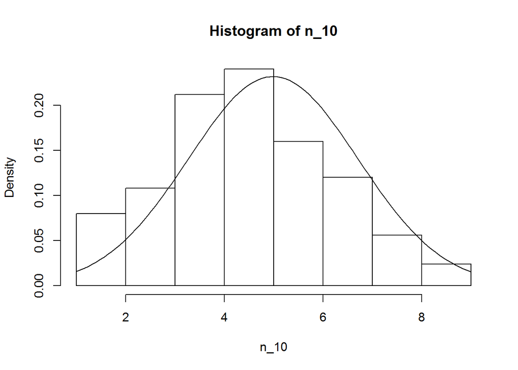

```r
# Histogram of n = 10
hist(n_10,probability = TRUE)
curve(dnorm(x,mean=mean(n_10),sd=sd(n_10)),add=TRUE)
```

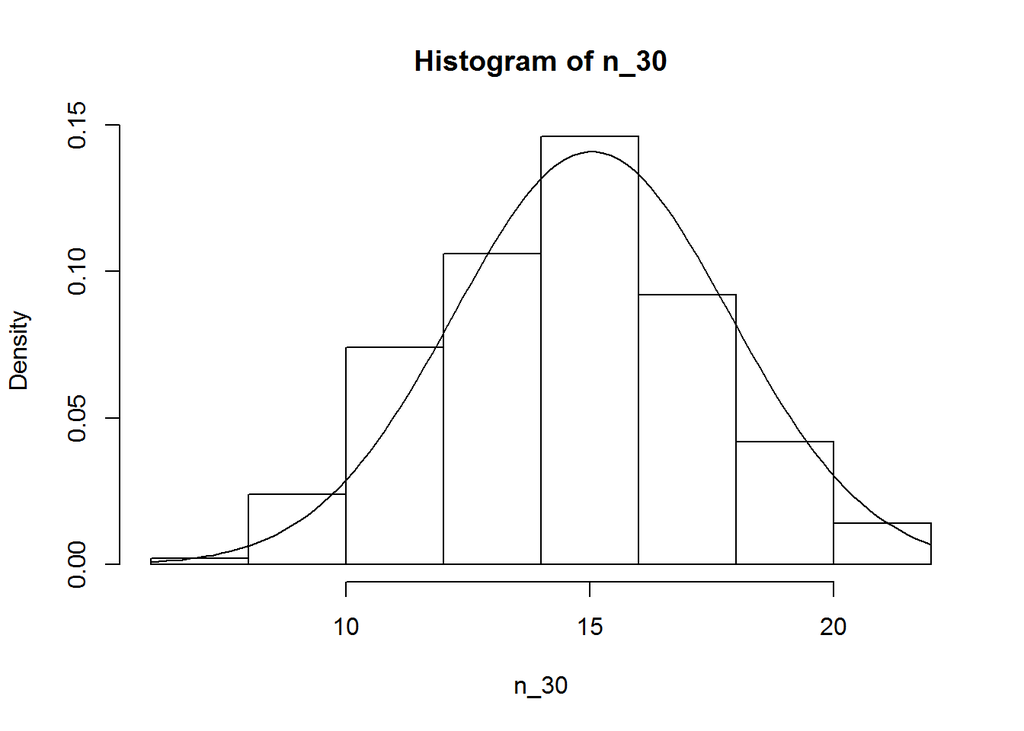

```r
# Histogram of n = 30
hist(n_30,probability = TRUE)
curve(dnorm(x,mean=mean(n_30),sd=sd(n_30)),add=TRUE)
```

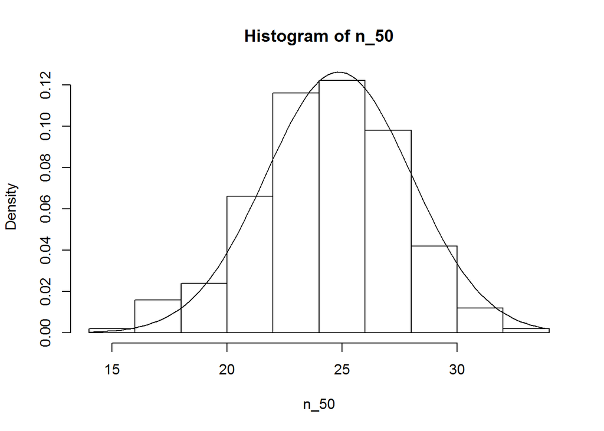

```r
# Histogram of n = 50
hist(n_50,probability = TRUE)
curve(dnorm(x,mean=mean(n_50),sd=sd(n_50)),add=TRUE)
```

## 1b.)(3pts.)

Now use the techniques described in class to improve graphs. Explain each step you choose including why you are making the change. You might consider creating density plots, changing color, axes, labeling, legend, and others for example.

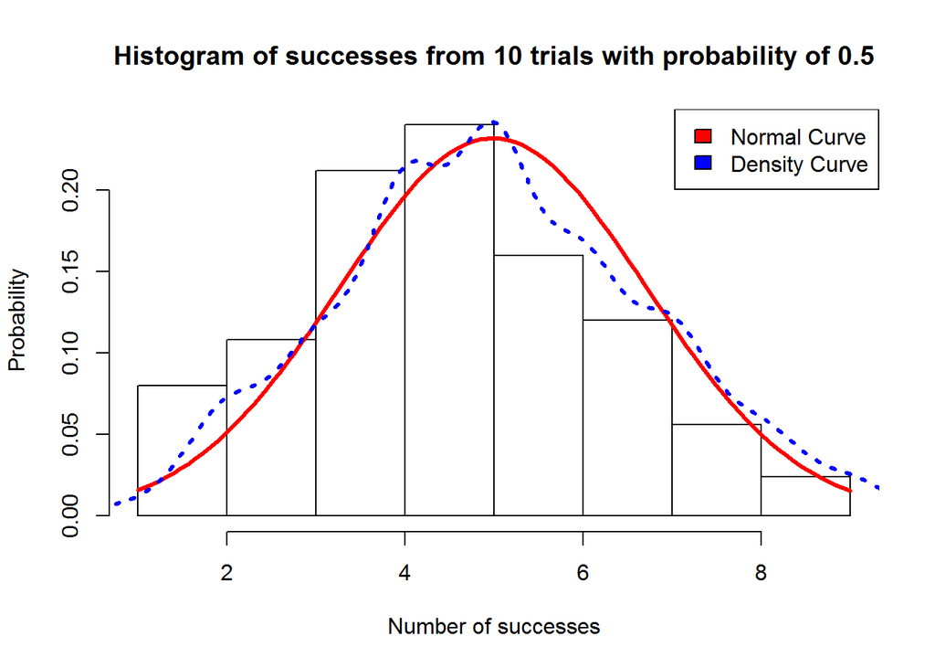

```r
# Create histogram of n = 10
hist(n_10,
     probability = TRUE,
     xlab = 'Number of successes',
     ylab = 'Probability',
     main = 'Histogram of successes from 10 trials with probability of 0.5')
curve(dnorm(x,mean=mean(n_10),sd=sd(n_10)),add=TRUE,col = 'Red',lwd=3)
# Add the density curve of actual data
lines(density(n_10),lty='dotted',lwd=3,col='Blue')
# Add legend
legend(legend = c('Normal Curve','Density Curve'), fil = c('Red','Blue'), 'topright')
```

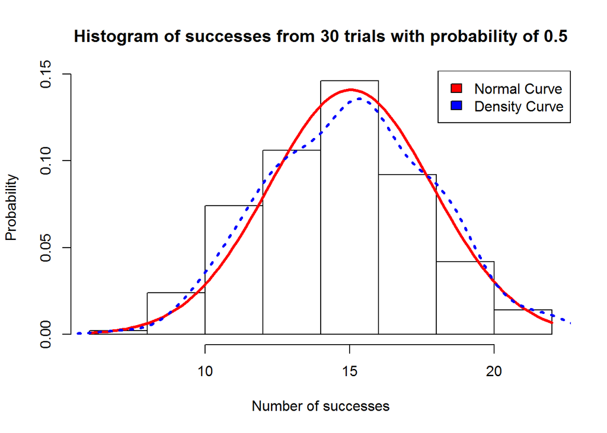

```r
# Create histogram of n = 30
hist(n_30,
     prob = TRUE,
     xlab = 'Number of successes',
     ylab = 'Probability',
     main = 'Histogram of successes from 30 trials with probability of 0.5')
curve(dnorm(x,mean=mean(n_30),sd=sd(n_30)),add=TRUE,col = 'Red',lwd=3)
# Add the density curve of actual data
lines(density(n_30),lty='dotted',lwd=3,col='Blue')
# Add legend
legend(legend = c('Normal Curve','Density Curve'), fil = c('Red','Blue'), 'topright')
```

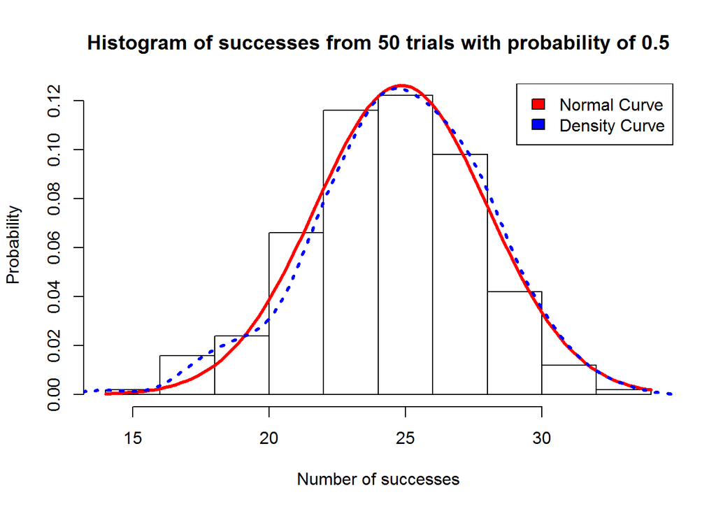

```r
# Create histogram of n = 50
hist(n_50,
     prob = TRUE,
     xlab = 'Number of successes',
     ylab = 'Probability',
     main = 'Histogram of successes from 50 trials with probability of 0.5')
curve(dnorm(x,mean=mean(n_50),sd=sd(n_50)),add=TRUE,col = 'Red',lwd=3)
# Add the density curve of actual data
lines(density(n_50),lty='dotted',lwd=3,col='Blue')
# Add legend
legend(legend = c('Normal Curve','Density Curve'), fil = c('Red','Blue'), 'topright')
```

**Steps:**

1. Make the axes more informative and add title to describe the graph
2. Change the color of normal curves to red to distinguish with the histogram
3. Make the normal curve wider to be more noticeable
4. Add the density curve of actual data to the graph, make it blue dotted line to differentiate it from the normal curve
5. Add legend to explain different curves

# Q2.) (2pts.)

Why do you think the Data Life Cycle is crucial to understanding the opportunities and challenges of making the most of digital data? Give two examples.

**Answer**:

1. Be able to clean the data and extract useful information from the data is important for any projects. It is hard to find valuable information from the data if the data is not well-organized. And even the data is well-organized to some level, if people do not know skills and techniques to do data mining, they will overlook many useful information hided behind the data
2. Be aware of preserving the data and document the work properly is also crucial for the use of data in the future. If the data is not well-preserved and the works were not well-documented, it will make either the author himself/herself or other people hard to understand the code that has been made years ago or try replicate the work

Part 2

# 3.) San Francisco Housing Data

```r
# Clear the current workspace
rm(list=ls())
```

Load the data into R.

```r
load(url("http://www.stanford.edu/~vcs/StatData/SFHousing.rda"))
```

# (2 pts.)

What is the name and class of each object you have loaded into your workspace?

Your code below

```r
# Name of objects
objects()
```

```
## [1] "cities"  "housing"
```

```r
# Classes of each objects
class(cities)
```

```
## [1] "data.frame"
```

```r
class(housing)
```

```
## [1] "data.frame"
```

What are the names of the vectors in housing?

Your code below

```r
names(housing)
```

```
##  [1] "county"  "city"    "zip"     "street"  "price"   "br"      "lsqft"
##  [8] "bsqft"   "year"    "date"    "long"    "lat"     "quality" "match"
## [15] "wk"
```

How many observations are in housing?

Your code below

```r
dim(housing)[1]
```

```
## [1] 281506
```

Your answer here

**Answer**: Housing has 281506 observations.

Explore the data using the summary function. Describe in words two problems that you see with the data.

Write your response here

```r
summary(housing)
```

```
##                  county                 city             zip
##  Santa Clara County :70424   Oakland      : 14730   94565  :  4595
##  Alameda County     :60410   Santa Rosa   :  9917   94509  :  4302
##  Contra Costa County:59381   Fremont      :  9414   95123  :  4023
##  Solano County      :23404   San Francisco:  8137   95687  :  3652
##  San Mateo County   :22558   Evergreen    :  7947   94533  :  3472
##  Sonoma County      :21676   Antioch      :  7726   (Other):261457
##  (Other)            :23653   (Other)      :223635   NA's   :     5
##     street              price                br            lsqft
##  Length:281506      Min.   :   22000   Min.   :1.000   Min.   :       19
##  Class :character   1st Qu.:  400000   1st Qu.:2.000   1st Qu.:     4000
##  Mode  :character   Median :  530000   Median :3.000   Median :     5760
##                     Mean   :  602000   Mean   :3.024   Mean   :    65939
##                     3rd Qu.:  700000   3rd Qu.:4.000   3rd Qu.:     7701
##                     Max.   :20000000   Max.   :8.000   Max.   :418611600
##                                                        NA's   :21687
##      bsqft              year           date
##  Min.   :    122   Min.   :   0   Min.   :2003-04-27 02:00:00
##  1st Qu.:   1121   1st Qu.:1954   1st Qu.:2004-02-08 02:00:00
##  Median :   1430   Median :1971   Median :2004-10-24 02:00:00
##  Mean   :   1624   Mean   :1966   Mean   :2004-11-01 18:06:12
##  3rd Qu.:   1882   3rd Qu.:1985   3rd Qu.:2005-07-24 02:00:00
##  Max.   :1868120   Max.   :3894   Max.   :2006-06-04 02:00:00
##  NA's   :426       NA's   :9202
##       long             lat
##  Min.   :-123.6   Min.   :36.98
##  1st Qu.:-122.3   1st Qu.:37.50
##  Median :-122.1   Median :37.77
##  Mean   :-122.1   Mean   :37.78
##  3rd Qu.:-121.9   3rd Qu.:38.00
##  Max.   :-121.5   Max.   :38.85
##  NA's   :23316    NA's   :23316
##                                       quality
##  QUALITY_ADDRESS_RANGE_INTERPOLATION      :170719
##  gpsvisualizer                            : 31084
##  QUALITY_CITY_CENTROID                    : 20473
##  QUALITY_EXACT_PARCEL_CENTROID            : 17208
##  QUALITY_ZIP_CODE_TABULATION_AREA_CENTROID: 14980
##  (Other)                                  :  3726
##  NA's                                     : 23316
##               match              wk
##  Exact           :197044   Min.   :2003-04-21
##  Relaxed         : 30570   1st Qu.:2004-02-01
##  Relaxed; Soundex: 23338   Median :2004-10-18
##  Soundex         :  2573   Mean   :2004-10-26
##  1               :  2244   3rd Qu.:2005-07-18
##  (Other)         :  2421   Max.   :2006-05-29
##  NA's            : 23316
```

**Answer**:

1. Variable “year” contains zero value
2. Variable “year” contains unreasonable extreme value (3894)
3. Variable “bsqft” has extreme high value
4. Variable “price” has extreme high value

# Q5. (2 pts.)

We will work the houses in Albany, Berkeley, Piedmont, and Emeryville only. Subset the data frame so that we have only houses in these cities and keep only the variables city, zip, price, br, bsqft, and year Call this new data frame BerkArea. This data frame should have 4059 observations and 6 variables.

```r
BerkArea <-
  subset(
    housing,
    city %in% c('Albany', 'Berkeley', 'Piedmont', 'Emeryville'),
    select = c(city, zip, price, br, bsqft, year)
  )
# Remove extra levels in city
BerkArea$city <-factor(BerkArea$city)
```

# Q6. (2 pts.)

We are interested in making plots of price and size of house, but before we do this we will further subset the data frame to remove the unusually large values. Use the quantile function to determine the 99th percentile of price and bsqft and eliminate all of those houses that are above either of these 99th percentiles. Call this new data frame BerkArea, as well. It should have 3999 observations.

```r
BerkArea <-
  BerkArea[BerkArea$price < quantile(BerkArea$price, 0.99) &
           BerkArea$bsqft < quantile(BerkArea$bsqft, 0.99,na.rm = TRUE),]
```

# Q7 (2 pts.)

Create a new vector that is called pricepsqft by dividing the sale price by the square footage Add this new variable to the data frame.

```r
pricepsqft <- BerkArea$price/BerkArea$bsqft
BerkArea['pricepsqft'] <- pricepsqft
```